# NEPA Decarbonization Technology Analysis: Deliverable 2

Programmatic & Tiered Reviews

Published

April 9, 2026

## Executive Summary

**Key Findings**

This report delivers:

> Data on programmatic and tiered reviews: how many tiered reviews are there compared to total and are they completed faster?

# Methodology

We identified programmatic and tiered reviews within the NEPATEC 2.0 decarbonization technology EA/EIS corpus using a two-stage extraction approach applied to all 1,326 EA and EIS projects.

**Stage 1 — Title detection:** Project titles were scanned for explicit programmatic indicators. A title match immediately classifies a project as programmatic with high confidence.

**Stage 2 — Regex extraction from documents:** For projects not resolved by title, the first 60 pages of each project’s main documents were searched using pattern matching. Two parallel detection tasks ran on each page: (1) checking whether the document itself is a programmatic review, and (2) looking for tiering language indicating the review builds on a prior programmatic document. A false-positive filter excluded non-NEPA uses of “tier” before any match was accepted.

**Sample search patterns used:**

| Detection target | Example patterns |
| --- | --- |
| Programmatic (title/text) | “programmatic,” “PEIS,” “PEA,” “Generic EIS,” “Tier 1 EIS” |
| Programmatic (document text) | “this programmatic EIS/EA,” “purpose of this programmatic,” “this PEIS analyzes” |
| Tiered (document text) | “this EA tiers from the [PEIS],” “tiers to the…PEIS,” “site-specific EA that tiers from” |
| False positives excluded | EPA Tier 1–4 engine standards, road tier classifications, “tiered pricing/rate” |

**Definitions:**

| Term | Meaning |
| --- | --- |
| **Standard** | A typical, stand-alone EA or EIS that neither constitutes nor tiers from a programmatic review |
| **Programmatic** | A Programmatic EIS (PEIS) or Programmatic EA (PEA) covering a class of actions or a geographic region |
| **Tiered** | A site-specific EA or EIS that explicitly tiers from a prior programmatic review |

# Review Type Snapshot

Figure 1 shows the overall distribution of review types across 1,326 decarbonization technology EA/EIS projects. The vast majority (87.9%) are standard reviews. Programmatic reviews (128 projects) and tiered reviews (33 projects) together represent 12.1% of the corpus.

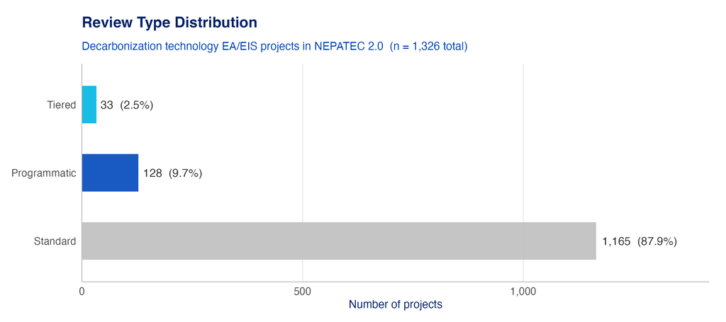

Figure 1: Review type distribution across 1,326 decarbonization technology EA/EIS projects in NEPATEC 2.0.

# Review Type by NEPA Process

Figure 2 breaks down review types by NEPA process (EA vs. EIS). The left panel shows proportional shares within each process type; the right panel shows absolute counts for non-standard reviews by process.

Programmatic reviews appear in both EA and EIS processes—programmatic EISs (PEIS) are more common, which makes sense given that PEIS are the canonical instrument for landscape-scale or policy-level NEPA reviews. Tiered reviews in this dataset are predominantly EAs, consistent with the idea that tiered reviews leverage prior programmatic analysis to streamline site-specific assessments that might otherwise require a full EIS.

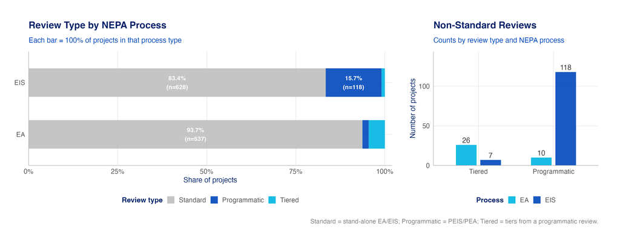

Figure 2: Review type distribution by NEPA process. Left: proportional shares within each process type; Right: absolute counts for non-standard reviews by process.

# Who Conducts Programmatic and Tiered Reviews?

## Lead Agencies

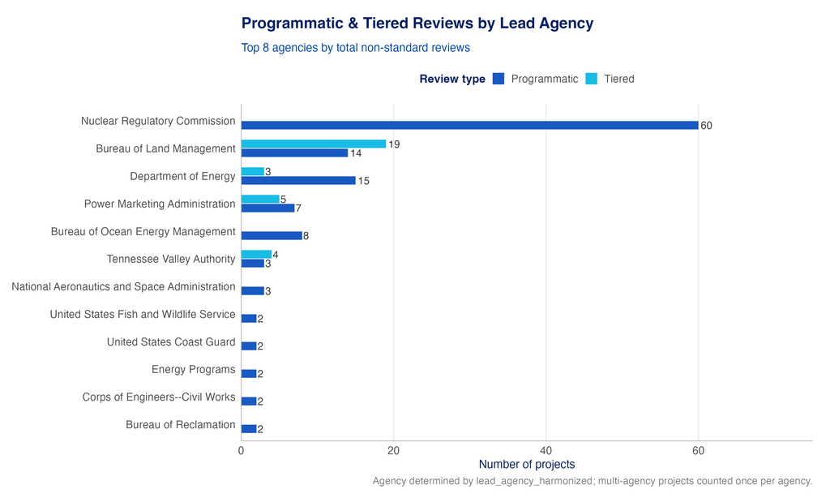

## By Department

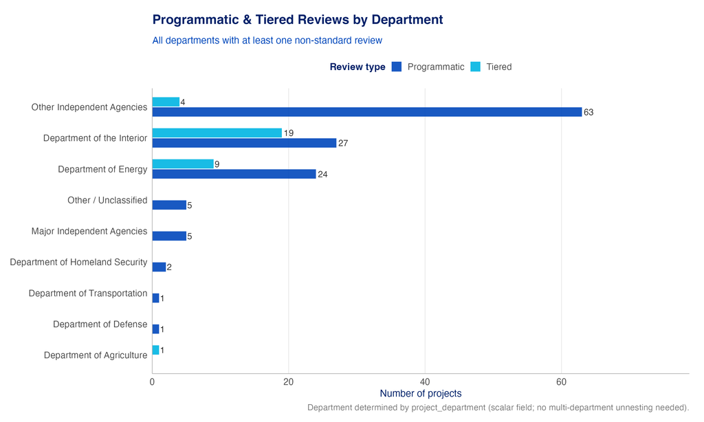

Figure 4: Programmatic and tiered reviews by parent department.

## Geographic Distribution

Figure 5 shows the top states for non-standard reviews. Western states dominate—California, Nevada, Washington, Colorado, and Arizona each have ten or more programmatic or tiered projects—mirroring BLM’s land footprint and the concentration of utility-scale renewable energy siting in the West. Note that multi-state projects are counted once per state, so these totals reflect project-state combinations.

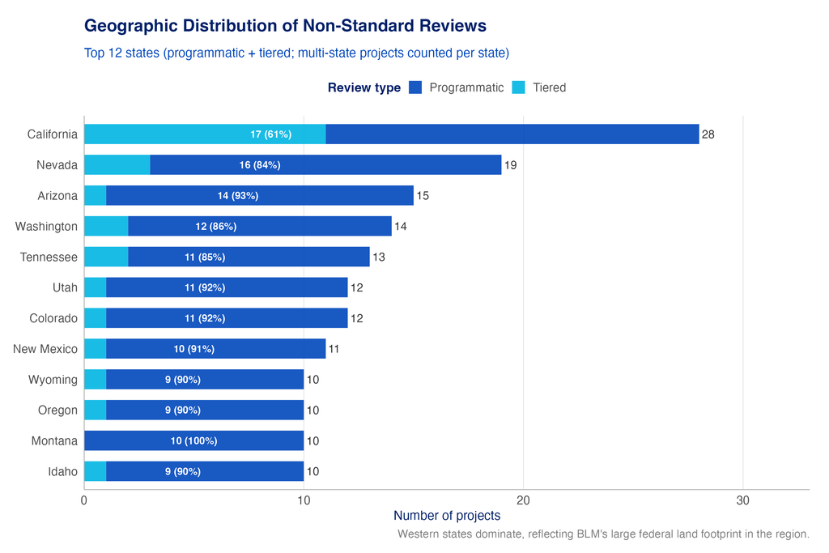

Figure 5: Top 12 states for programmatic and tiered decarbonization technology reviews (multi-state projects counted once per state).

# Review Duration

A central question for this deliverable is whether tiered reviews complete faster than standard reviews—the implicit rationale for tiering being that it reduces analytical burden by leveraging prior programmatic work. Figure 6 compares review duration (days from initiation to decision) across review types, separately for EA and EIS processes. Note that duration analysis is limited to projects with both a valid initiation date and a decision date; incomplete timeline coverage reduces sample sizes, particularly for non-standard review types.

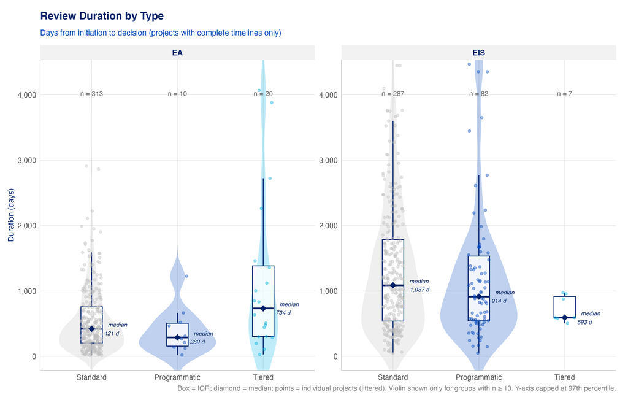

Figure 6: Review duration by type and NEPA process. Box = IQR; diamond = median; points = individual projects. Violin shown for groups with n ≥ 10. Y-axis capped at the 97th percentile.

Table 1: Descriptive statistics for review duration (days) by review type and NEPA process.

| Review Type | N | Days (initiation to decision) Mean | Days (initiation to decision) Median | Days (initiation to decision) SD | Days (initiation to decision) P25 | Days (initiation to decision) P75 | Days (initiation to decision) Min | Days (initiation to decision) Max |
| --- | --- | --- | --- | --- | --- | --- | --- | --- |
| EA |  |  |  |  |  |  |  |  |
| Programmatic | 10 | 395 | 289 | 353 | 157 | 507 | 21 | 1,228 |
| Standard | 313 | 610 | 421 | 755 | 204 | 758 | 14 | 7,226 |
| Tiered | 20 | 1,143 | 734 | 1,194 | 303 | 1,384 | 29 | 4,069 |
| EIS |  |  |  |  |  |  |  |  |
| Programmatic | 82 | 1,279 | 914 | 1,255 | 543 | 1,534 | 49 | 7,862 |
| Standard | 287 | 1,379 | 1,087 | 1,111 | 540 | 1,784 | 43 | 7,136 |
| Tiered | 7 | 725 | 593 | 201 | 586 | 917 | 505 | 973 |

Only projects with both a valid initiation date and decision date and positive duration are included.

**Key finding:** Tiered reviews are not systematically faster.

- **Tiered EAs** take a median of **734** days—longer than standard EAs (421 days). This is the opposite of the expected efficiency gain.
- **Programmatic EAs** (n = 10) appear shorter (median 289 days), but the sample is too small to draw conclusions.
- **Programmatic EISs** (n = 82) are modestly faster than standard EISs (914 vs. 1087 days), suggesting some efficiency benefit for the programmatic EIS instrument itself—but the difference is small relative to the overall spread.
- **Tiered EISs** have only 7 observations and cannot be interpreted reliably.

One possible explanation for the counterintuitive tiered EA finding: projects that explicitly tier from a programmatic review may be larger and more complex (e.g., utility-scale solar siting in BLM landscape plans), and this complexity drives the longer timeline rather than the tiering relationship per se. Controlling for project scope would require additional data.

# Tiered Review Parentage

Which programmatic reviews generate the most downstream tiered work? Figure 7 classifies the “tiers from” references extracted from each tiered project’s documents.

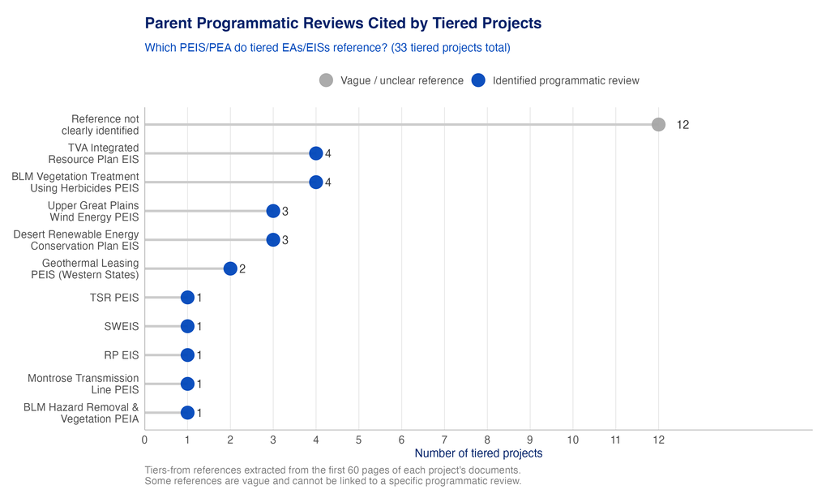

Figure 7: Parent programmatic reviews cited by the 33 tiered projects. Blue points = named programmatic reviews; gray = vague or unclear references that could not be linked to a specific PEIS/PEA.

A handful of programmatic reviews generate the bulk of identifiable tiered work, including the BLM Vegetation Treatment Using Herbicides PEIS, the TVA Integrated Resource Plan EIS, the Desert Renewable Energy Conservation Plan (DRECP) EIS, and the Upper Great Plains Wind Energy PEIS. Some tiered reviews reference the parent PEIS vaguely (e.g., “this EA incorporates by reference the analysis of…”), making the specific parent review unidentifiable from text alone.

# Examples

## Programmatic Reviews

Table 2 shows sample projects classified as programmatic reviews, with the evidence text that triggered the classification.

Table 2: Sample programmatic review projects with classification evidence.

| Project title | Process | Evidence text |
| --- | --- | --- |
| Buckeye Hills Regional Park 12kV Distribution Line Project | EA | “Tier 1 EIS” |
| Grand Coulee's Third Powerplant 500-kilovolt Transmission Line Replacement Project | EA | “EA-1679/initial_EA_1679_Preliminary_Environme_EA-1679-PEA-2011.pdf” |
| KORE Power − KOREPlex Facility | EA | “Tier 1 Environmental Impact Statement” |
| National Wind Technology Center Site Operations and Short-Term and Long-Term Improvement Programs | EA | “This programmatic environmental” |
| Parker-Davis Transmission System Routine Operation and Maintenance Project and Proposed Integrated Vegetation Management Program | EA | “Parker-Davis Transmission System Routine Operation and Maintenance Project and Proposed Integrated Vegetation Managem...” |
| Parker-Davis Transmission System Routine Operation and Maintenance Project and Proposed Integrated Vegetation Management Program | EA | “Parker-Davis Transmission System Routine Operation and Maintenance Project and Proposed Integrated Vegetation Managem...” |
| Programmatic Environmental Assessment for System-wide Operations and Maintenance Activities and Integrated Vegetation Management Program | EA | “Programmatic Environmental Assessment for System-wide Operations and Maintenance Activities and Integrated Vegetation...” |
| Southern California Edison Eldorado-Lugo-Mohave Series Capacitor Project | EA | “Appendix M PEA Visual Simulations Updated.pdf” |
| Town of Hempstead Wind-to-Hydrogen Project | EA | “generic environmental impact statement” |
| Uranium Leasing Program | EA | “Uranium Leasing Program Final Programmatic Environmental Assessment” |

## Tiered Reviews

Table 3 shows sample tiered reviews with the parent programmatic review they reference and the evidence text.

Table 3: Sample tiered review projects with parent PEIS/PEA reference and classification evidence.

| Project title | Process | Tiers from | Evidence |
| --- | --- | --- | --- |
| 2025 Geothermal Competitive Lease Sale | EA | that analysis | “this EA tiers to that analysis.” |
| 2025 Geothermal Competitive Lease Sale Malheur Field Office | EA | Programmatic Environmental Impact Statement for Geothermal Leasing in the Western | “This EA is tiered to the Programmatic Environmental Impact Statement for Geothermal Leasing in the Western ” |
| ASTAC Terrestrial Fiber Optic Cable between Atqasuk and Utqiaġvik | EA | these documents and the documents are incorporated by reference | “This EA is tiered to these documents and the documents are incorporated by reference.” |
| Arica Solar Project and Victory Pass Solar Project | EA | Desert Renewable Energy Conservation Plan (DRECP) Environmental Impact | “The EA tiers to the Desert Renewable Energy Conservation Plan (DRECP) Environmental Impact ” |
| Arica and Victory Pass Solar Projects | EA | Desert Renewable Energy Conservation Plan (DRECP) Environmental Impact | “The EA tiers to the Desert Renewable Energy Conservation Plan (DRECP) Environmental Impact ” |
| Barrow Utilities and Electric Cooperative, Inc. New Switchgear Building | EA | this document and the documents incorporated by reference | “This EA is tiered to this document and the documents incorporated by reference.” |
| Coalinga #1 San Miguel 70kV Line Monterey County | EA | BLM’s Programmatic EA for Hazard Removal and Vegetation | “This EA is tiered to the BLM’s Programmatic EA for Hazard Removal and Vegetation ” |
| Desert Harvest Solar Project Integrated Weed Management Plan Implementation for Operations and Maintenance Activities | EA | BLM’s Vegetation Treatment Using Herbicides on BLM Lands in 17 Western | “The EA tiers to BLM’s Vegetation Treatment Using Herbicides on BLM Lands in 17 Western ” |
| Desert Sunlight Solar Farm Project | EIS | BLM’s | “The EA tiers from the BLM’s ” |
| Gateway West Transmission Line Project | EA | and incorporates by reference the analysis and | “this EA is tiered to and incorporates by reference the analysis and ” |

*Report generated 2026-04-09 | NEPA Decarbonization Technology Analysis*